# Practical Machine Learning Assignment

Rebecca Weingarten

May 19, 2016

## **Background**

Using devices such as Jawbone Up, Nike FuelBand, and Fitbit it is now possible to collect a large amount of data about personal activity relatively inexpensively. These type of devices are part of the quantified self movement Â- a group of enthusiasts who take measurements about themselves regularly to improve their health, to find patterns in their behavior, or because they are tech geeks.

One thing that people regularly do is quantify how much of a particular activity they do, but they rarely quantify how well they do it. In this data set, the participants were asked to perform barbell lifts correctly and incorrectly in 5 different ways. More information is available from the website here: http://groupware.les.inf.puc-rio.br/har (see the section on the Weight Lifting Exercise Dataset).

In this project, the goal will be to use data from accelerometers on the belt, forearm, arm, and dumbell of 6 participants toto predict the manner in which praticipants did the exercise.

The dependent variable or response is the “classe” variable in the training set.

**Data**

Download and load the data:

```r
library(caret)
```

```r
download.file("https://d396qusza40orc.cloudfront.net/predmachlearn/pml-training.csv", destfile = "U:/Documents/_rworking/pml-training.csv")
download.file("http://d396qusza40orc.cloudfront.net/predmachlearn/pml-testing.csv", destfile = "U:/Documents/_rworking/pml-testing.csv")


trainingOrg = read.csv("U:/Documents/_rworking/pml-training.csv", na.strings=c("", "NA", "NULL"))
# data.train =  read.csv("https://d396qusza40orc.cloudfront.net/predmachlearn/pml-training.csv", na.strings=c("", "NA", "NULL"))

testingOrg = read.csv("U:/Documents/_rworking/pml-testing.csv", na.strings=c("", "NA", "NULL"))
dim(trainingOrg)
```

```
## [1] 19622   160
```

**Pre-screening the data**

There are several approaches for reducing the number of predictors.

Remove variables that we believe have too many NA values.

```
## [1] 19622    60
```

Remove unrelevant variables There are some unrelevant variables that can be removed as they are unlikely to be related to dependent variable.

```
## [1] 19622    53
```

Check the variables that have extremely low variance (this method is useful nearZeroVar() )

```
## [1] 19622    53
```

Remove highly correlated variables 90% (using for example findCorrelation() )

```
## [1] 52 52
```

There are 52 variables.

**Plot Variables**

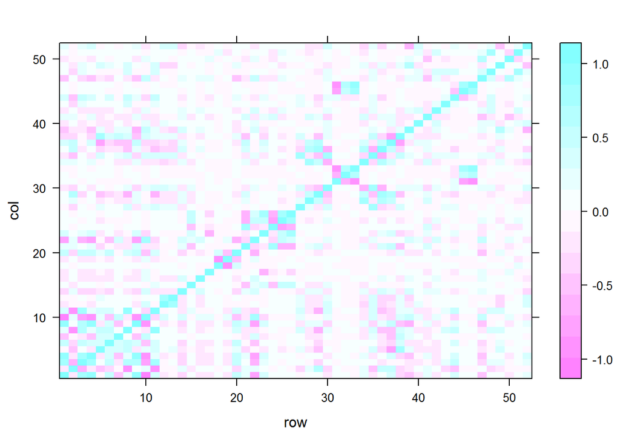

Next I remove the variables with high correlation:

```
## Compare row 10  and column  1 with corr  0.992
##   Means:  0.27 vs 0.168 so flagging column 10
## Compare row 1  and column  9 with corr  0.925
##   Means:  0.25 vs 0.164 so flagging column 1
## Compare row 9  and column  4 with corr  0.928
##   Means:  0.233 vs 0.161 so flagging column 9
## Compare row 8  and column  2 with corr  0.966
##   Means:  0.245 vs 0.157 so flagging column 8
## Compare row 19  and column  18 with corr  0.918
##   Means:  0.091 vs 0.158 so flagging column 18
## Compare row 46  and column  31 with corr  0.914
##   Means:  0.101 vs 0.161 so flagging column 31
## Compare row 46  and column  33 with corr  0.933
##   Means:  0.083 vs 0.164 so flagging column 33
## All correlations <= 0.9
```

```
## [1] 19622    46
```

We get 19622 samples and 46 variables.

**Split data to training and testing for cross validation.**

```
## [1] 13737    46
```

```
## [1] 5885   46
```

We got 13737 samples and 46 variables for training, 5885 samples and 46 variables for testing.

**Analysis** *Regression Tree*

Now we fit a tree to these data, and summarize and plot it. First, we use the ‘tree’ package. It is much faster than ‘caret’ package.

```
##
## Classification tree:
## tree(formula = classe ~ ., data = training)
## Variables actually used in tree construction:
##  [1] "pitch_forearm"     "magnet_belt_y"     "accel_forearm_z"
##  [4] "magnet_dumbbell_y" "roll_forearm"      "magnet_dumbbell_z"
##  [7] "pitch_belt"        "yaw_belt"          "accel_dumbbell_y"
## [10] "accel_forearm_x"   "magnet_belt_z"     "magnet_arm_x"
## [13] "accel_dumbbell_z"  "gyros_belt_z"
## Number of terminal nodes:  24
## Residual mean deviance:  1.512 = 20730 / 13710
## Misclassification error rate: 0.2806 = 3855 / 13737
```

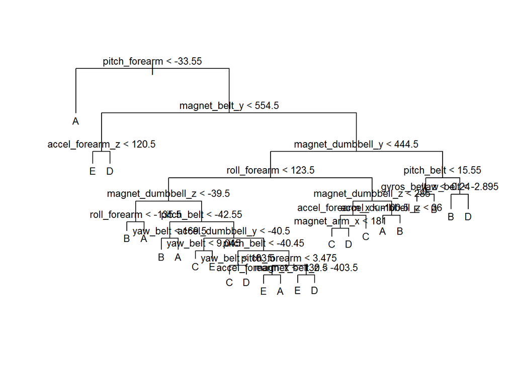

This tree has a ton of data and needs to be parsed down. First I am going to check the performance of the tree on the testing data by cross validation.

**Cross Validation**

```
## [1] 0.7180969
```

**Cross Validation** This shows a more narrow scope of the date:

```
## $size
##  [1] 24 23 22 21 20 19 18 17 16 13  7  5  1
##
## $dev
##  [1] 3898 4003 4035 4578 4880 4936 4936 4960 4960 6745 6745 7237 9831
##
## $k
##  [1]  -Inf  85.0  96.0 134.0 145.0 152.0 154.0 159.0 163.0 194.0 201.5
## [12] 247.5 650.5
##
## $method
## [1] "misclass"
##
## attr(,"class")
## [1] "prune"         "tree.sequence"
```

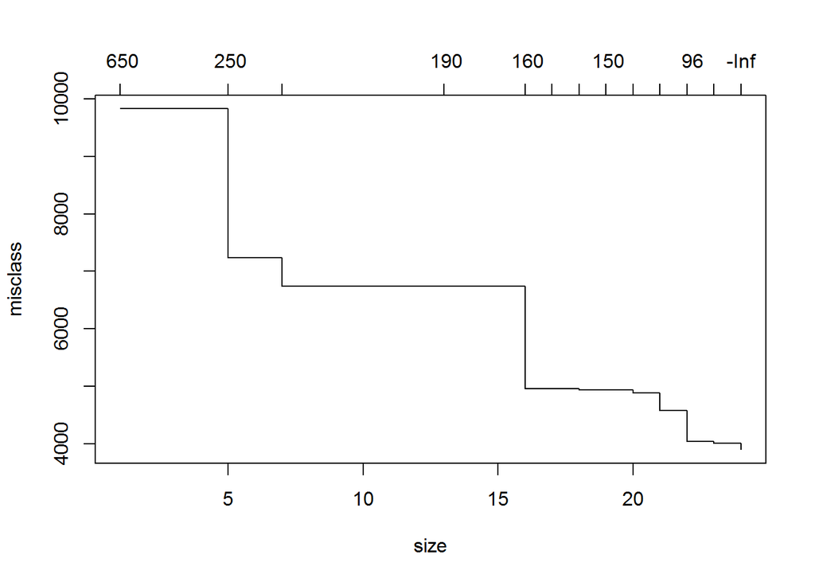

Suppose we prune it at size of nodes at 18.

```
## [1] 0.6564146
```

The single tree is not good enough, so we are going to use bootstrap to improve the accuracy. We are going to try random forests.

**Random Forests**

These methods use trees as building blocks to build more complex models. Random forests build lots of bushy trees, and then average them to reduce the variance.

```
##
## Call:
##  randomForest(formula = classe ~ ., data = training, ntree = 100,      importance = TRUE)
##                Type of random forest: classification
##                      Number of trees: 100
## No. of variables tried at each split: 6
##
##         OOB estimate of  error rate: 0.68%
## Confusion matrix:
##      A    B    C    D    E class.error
## A 3901    4    1    0    0 0.001280082
## B   11 2640    7    0    0 0.006772009
## C    0   21 2367    8    0 0.012103506
## D    0    0   27 2222    3 0.013321492
## E    0    0    3    9 2513 0.004752475
```

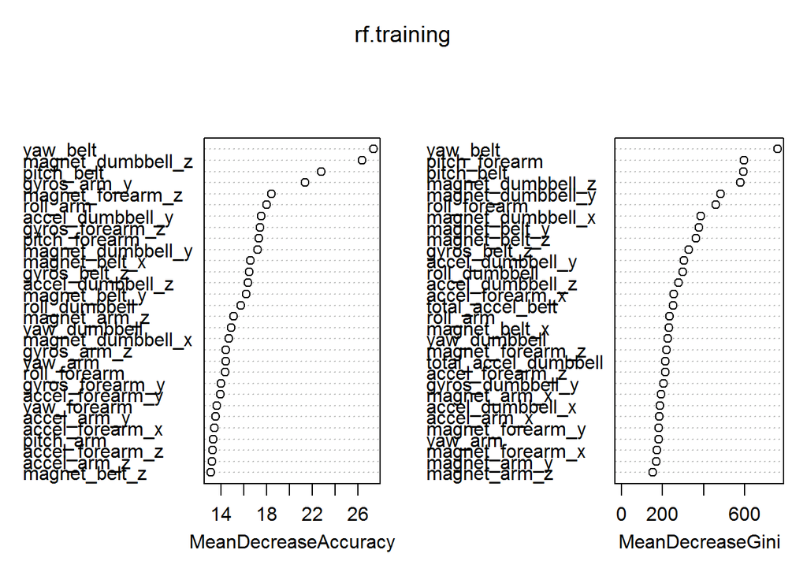